# lesson3-planet

## Multi-label prediction with Planet Amazon dataset

```python
%reload_ext autoreload
%autoreload 2
%matplotlib inline
```

```python
from fastai.vision import *
```

## Getting the data

The planet dataset isn't available on the [fastai dataset page](https://course.fast.ai/datasets) due to copyright restrictions. You can download it from Kaggle however. Let's see how to do this by using the [Kaggle API](https://github.com/Kaggle/kaggle-api) as it's going to be pretty useful to you if you want to join a competition or use other Kaggle datasets later on.

First, install the Kaggle API by uncommenting the following line and executing it, or by executing it in your terminal (depending on your platform you may need to modify this slightly to either add `source activate fastai` or similar, or prefix `pip` with a path. Have a look at how `conda install` is called for your platform in the appropriate *Returning to work* section of https://course.fast.ai/. (Depending on your environment, you may also need to append "--user" to the command.)

```python
#! {sys.executable} -m pip install kaggle --upgrade
```

Then you need to upload your credentials from Kaggle on your instance. Login to kaggle and click on your profile picture on the top left corner, then 'My account'. Scroll down until you find a button named 'Create New API Token' and click on it. This will trigger the download of a file named 'kaggle.json'.

Upload this file to the directory this notebook is running in, by clicking "Upload" on your main Jupyter page, then uncomment and execute the next two commands (or run them in a terminal). For Windows, uncomment the last two commands.

```python
#! mkdir -p ~/.kaggle/
#! mv kaggle.json ~/.kaggle/

# For Windows, uncomment these two commands
# ! mkdir %userprofile%\.kaggle
# ! move kaggle.json %userprofile%\.kaggle
```

You're all set to download the data from [planet competition](https://www.kaggle.com/c/planet-understanding-the-amazon-from-space). You **first need to go to its main page and accept its rules**, and run the two cells below (uncomment the shell commands to download and unzip the data). If you get a `403 forbidden` error it means you haven't accepted the competition rules yet (you have to go to the competition page, click on *Rules* tab, and then scroll to the bottom to find the *accept* button).

```python
path = Config.data_path()/'planet'
path.mkdir(parents=True, exist_ok=True)
path
```

```
PosixPath('/storage/planet')
```

```python
#! kaggle competitions download -c planet-understanding-the-amazon-from-space -f train-jpg.tar.7z -p {path}
#! kaggle competitions download -c planet-understanding-the-amazon-from-space -f train_v2.csv -p {path}
#! unzip -q -n {path}/train_v2.csv.zip -d {path}
```

To extract the content of this file, we'll need 7zip, so uncomment the following line if you need to install it (or run `sudo apt install p7zip-full` in your terminal).

```python
#! conda install --yes --prefix {sys.prefix} -c haasad eidl7zip
```

And now we can unpack the data (uncomment to run - this might take a few minutes to complete).

```python
! 7za -bd -y -so x {path}/train-jpg.tar.7z | tar xf - -C {path.as_posix()}
```

```
^C

ERROR: E_FAIL


Break signaled
```

## Multiclassification

Contrary to the pets dataset studied in last lesson, here each picture can have multiple labels. If we take a look at the csv file containing the labels (in 'train_v2.csv' here) we see that each 'image_name' is associated to several tags separated by spaces.

```python
df = pd.read_csv(path/'train_v2.csv')
df.head()
```

|  | image_name | tags |
| --- | --- | --- |
| 0 | train_0 | haze primary |
| 1 | train_1 | agriculture clear primary water |
| 2 | train_2 | clear primary |
| 3 | train_3 | clear primary |
| 4 | train_4 | agriculture clear habitation primary road |

To put this in a `DataBunch` while using the [data block API](https://docs.fast.ai/data_block.html), we then need to using `ImageList` (and not `ImageDataBunch`). This will make sure the model created has the proper loss function to deal with the multiple classes.

```python
# DATA AUGMENTATION STEP. Helps model generalise better
# transforms by default only flips images horizontally - for satellite images we want vertical flips too
# max_warp = perspective warping (ie looking at something from below vs above). We don't want this here
tfms = get_transforms(flip_vert=True, max_lighting=0.1, max_zoom=1.05, max_warp=0.)
```

We use parentheses around the data block pipeline below, so that we can use a multiline statement without needing to add '\'.

```python
# this is how the data block API works:
# create an image list from csv with params, split into traning and validation and label
np.random.seed(42)
src = (ImageList.from_csv(path, 'train_v2.csv', folder='train-jpg', suffix='.jpg')
       .split_by_rand_pct(0.2)
       .label_from_df(label_delim=' '))
```

```python
# can increase size if you want a better model
# TRANSFER LEARNING on a model trained well on size 128 images, learning for a 'new' dataset of size 256 images
data = (src.transform(tfms, size=128)
        .databunch().normalize(imagenet_stats))
```

[output not shown]

[output cut: 8 more lines]

[output not shown]

`show_batch` still works, and show us the different labels separated by `;`.

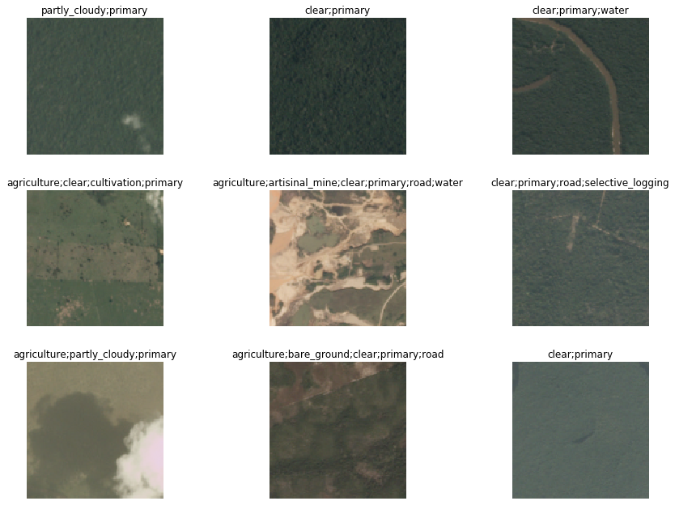

```python
data.show_batch(rows=3, figsize=(12,9))
```

To create a `Learner` we use the same function as in lesson 1. Our base architecture is resnet50 again, but the metrics are a little bit differeent: we use `accuracy_thresh` instead of `accuracy`. In lesson 1, we determined the predicition for a given class by picking the final activation that was the biggest, but here, each activation can be 0. or 1. `accuracy_thresh` selects the ones that are above a certain threshold (0.5 by default) and compares them to the ground truth.

As for Fbeta, it's the metric that was used by Kaggle on this competition. See [here](https://en.wikipedia.org/wiki/F1_score) for more details.

```python
arch = models.resnet50
```

```python
# changed metrics - this doesn't affect how the model trains; it just affects what is printed out for each iteration
# Kaggle scored this particular competition on the F-score

# using partial to specify threshold because the learner is calling the metrics functions itself
acc_02 = partial(accuracy_thresh, thresh=0.2)
f_score = partial(fbeta, thresh=0.2)
learn = cnn_learner(data, arch, metrics=[acc_02, f_score])
```

```
Downloading: "https://download.pytorch.org/models/resnet50-19c8e357.pth" to /home/ubuntu/.torch/models/resnet50-19c8e357.pth
```

We use the LR Finder to pick a good learning rate.

```python
learn.lr_find()
```

```
LR Finder is complete, type {learner_name}.recorder.plot() to see the graph.
```

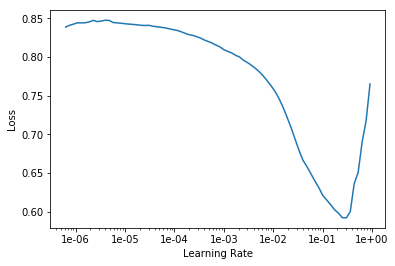

```python
learn.recorder.plot()
```

Then we can fit the head of our network.

```python
lr = 0.01
```

```python
# when fitting further, could fit on only previously misclassified examples
# might want to use a higher learning rate than usual as these samples are already considered 'interesting'
learn.fit_one_cycle(5, slice(lr))
```

Total time: 03:30

| epoch | train_loss | valid_loss | accuracy_thresh | fbeta |
| --- | --- | --- | --- | --- |
| 1 | 0.125128 | 0.110038 | 0.944010 | 0.904893 |
| 2 | 0.112533 | 0.101303 | 0.955964 | 0.910774 |
| 3 | 0.100574 | 0.093255 | 0.955187 | 0.918653 |
| 4 | 0.096056 | 0.087997 | 0.954983 | 0.924016 |
| 5 | 0.092320 | 0.086761 | 0.956400 | 0.925110 |

```python
learn.save('stage-1-rn50')
```

...And fine-tune the whole model:

```python
learn.unfreeze()
```

```
LR Finder complete, type {learner_name}.recorder.plot() to see the graph.
```

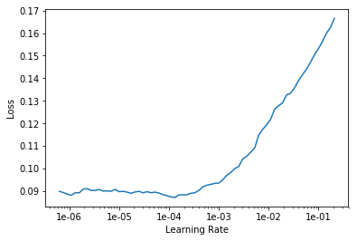

```python
learn.lr_find()
learn.recorder.plot()
```

```python
# rule of thumb: take 10x smaller than before it rises, and then lr/5 or lr/10 further on
learn.fit_one_cycle(5, slice(1e-5, lr/5))
```

Total time: 04:00

| epoch | train_loss | valid_loss | accuracy_thresh | fbeta |
| --- | --- | --- | --- | --- |
| 1 | 0.097016 | 0.094868 | 0.952004 | 0.916215 |
| 2 | 0.095774 | 0.088899 | 0.954540 | 0.922340 |
| 3 | 0.090646 | 0.085958 | 0.959249 | 0.924921 |
| 4 | 0.085097 | 0.083291 | 0.958849 | 0.928195 |
| 5 | 0.079197 | 0.082855 | 0.958602 | 0.928259 |

```python
learn.save('stage-2-rn50')
```

```python
# transfer learning using new databunch of size 256 images
data = (src.transform(tfms, size=256)
        .databunch().normalize(imagenet_stats))

# replace data in learner with new databunch
learn.data = data


data.train_ds[0][0].shape
```

[output not shown]

[output cut: 11 more lines]

[output not shown]

```python
learn.freeze()
```

```
LR Finder complete, type {learner_name}.recorder.plot() to see the graph.
```

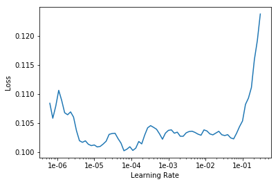

```python
learn.lr_find()
learn.recorder.plot()
```

```python
lr=1e-2/2
```

```python
learn.fit_one_cycle(5, slice(lr))
```

Total time: 09:01

| epoch | train_loss | valid_loss | accuracy_thresh | fbeta |
| --- | --- | --- | --- | --- |
| 1 | 0.087761 | 0.085013 | 0.958006 | 0.926066 |
| 2 | 0.087641 | 0.083732 | 0.958260 | 0.927459 |
| 3 | 0.084250 | 0.082856 | 0.958485 | 0.928200 |
| 4 | 0.082347 | 0.081470 | 0.960091 | 0.929166 |
| 5 | 0.078463 | 0.080984 | 0.959249 | 0.930089 |

```python
learn.save('stage-1-256-rn50')
```

```python
learn.unfreeze()
```

```python
learn.fit_one_cycle(5, slice(1e-5, lr/5))
```

Total time: 11:25

| epoch | train_loss | valid_loss | accuracy_thresh | fbeta |
| --- | --- | --- | --- | --- |
| 1 | 0.082938 | 0.083548 | 0.957846 | 0.927756 |
| 2 | 0.086312 | 0.084802 | 0.958718 | 0.925416 |
| 3 | 0.084824 | 0.082339 | 0.959975 | 0.930054 |
| 4 | 0.078784 | 0.081425 | 0.959983 | 0.929634 |
| 5 | 0.074530 | 0.080791 | 0.960426 | 0.931257 |

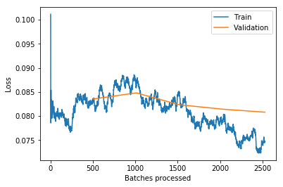

```python
learn.recorder.plot_losses()
```

```python
learn.save('stage-2-256-rn50')
```

You won't really know how you're going until you submit to Kaggle, since the leaderboard isn't using the same subset as we have for training. But as a guide, 50th place (out of 938 teams) on the private leaderboard was a score of `0.930`.

```python
learn.export()
```

## fin

(This section will be covered in part 2 - please don't ask about it just yet! :) )

```python
#! kaggle competitions download -c planet-understanding-the-amazon-from-space -f test-jpg.tar.7z -p {path}
#! 7za -bd -y -so x {path}/test-jpg.tar.7z | tar xf - -C {path}
#! kaggle competitions download -c planet-understanding-the-amazon-from-space -f test-jpg-additional.tar.7z -p {path}
#! 7za -bd -y -so x {path}/test-jpg-additional.tar.7z | tar xf - -C {path}
```

```python
test = ImageList.from_folder(path/'test-jpg').add(ImageList.from_folder(path/'test-jpg-additional'))
len(test)
```

```
61191
```

```python
learn = load_learner(path, test=test)
preds, _ = learn.get_preds(ds_type=DatasetType.Test)
```

```python
thresh = 0.2
labelled_preds = [' '.join([learn.data.classes[i] for i,p in enumerate(pred) if p > thresh]) for pred in preds]
```

```python
labelled_preds[:5]
```

```
['agriculture cultivation partly_cloudy primary road',
 'clear haze primary water',
 'agriculture clear cultivation primary',
 'clear primary',
 'partly_cloudy primary']
```

```python
fnames = [f.name[:-4] for f in learn.data.test_ds.items]
```

```python
df = pd.DataFrame({'image_name':fnames, 'tags':labelled_preds}, columns=['image_name', 'tags'])
```

```python
df.to_csv(path/'submission.csv', index=False)
```

```python
! kaggle competitions submit planet-understanding-the-amazon-from-space -f {path/'submission.csv'} -m "My submission"
```

Private Leaderboard score: 0.9296 (around 80th)